# Data Wrangling Project

In this project, we have studied data from the twitter account WeRateDogs. It is created for dog lovers who love watching other people dogs and express their love by evaluating the cuteness of these dogs. If we were mean, we would say that this is one of many ways of losing our precious time on the planet Earth that suppose to be creative and funny. Anyway, it is at least less expensive than having children. In this project, we had to gather data from many tweets with ratings and other fascinating information about dogs. The data is messy. So we have to clean it and combine them to draw some insights.

### Comments on cleaning process

The process of cleaning was evolving mostly around filling out missing values, getting rid of unnessary information, adjusting the format, removing typos and illogical outliers. In my humble personal opinion, whether we call these issues "quality issues" or "tidiness issues", it does matter. We had to take information from many sources and merge them into one csv file. The data may come from the api, sql databases, csv files and so on. What matters is what have to be done in order to extract usuful information for our analyses. These types of correction can be expected in most cleaning data analyst tasks. It is the bread and butter of daily work of most data analysts.

Here are the issues to correct:

**Quality Issues**

- the following columns: timestamp, retweeted_status_timestamp data types should be datatime instead of object type.
- the following columns in_reply_to_status_id and in_reply_to_user_id should be defined as integers, not as floats
- the rating_denominator column should be always 10. For some rows this value is different than 10.
- the name column has missing values, some names are not correct
- Changing dogs breeds names to lower letters in the doggo_pred_df dataframe
- Changing the tweet_id column datatype to integer for all dataframes in order to perform a successful merge
- Extracting the gender of a dog out of a tweet
- we have to remove unnecessary columns: 'in_reply_to_status_id', 'in_reply_to_user_id'
- Dropping duplicated urls in the twitter_df_clean dateframe
- Dropping duplicated jpg urls in the doggo_pred_df dateframe  
  **Tidiness Issues**
- combining 3 dataframes to create one master/main dataframe
- merging four dog_stages columns into a single one

# Analyzing and visualizing data

### Visualisation 1

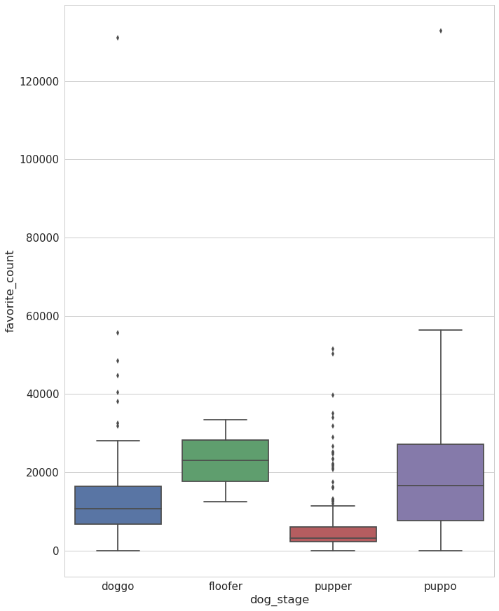

```python
sns.boxplot(data=main_df, x='dog_stage', y='favorite_count')
```

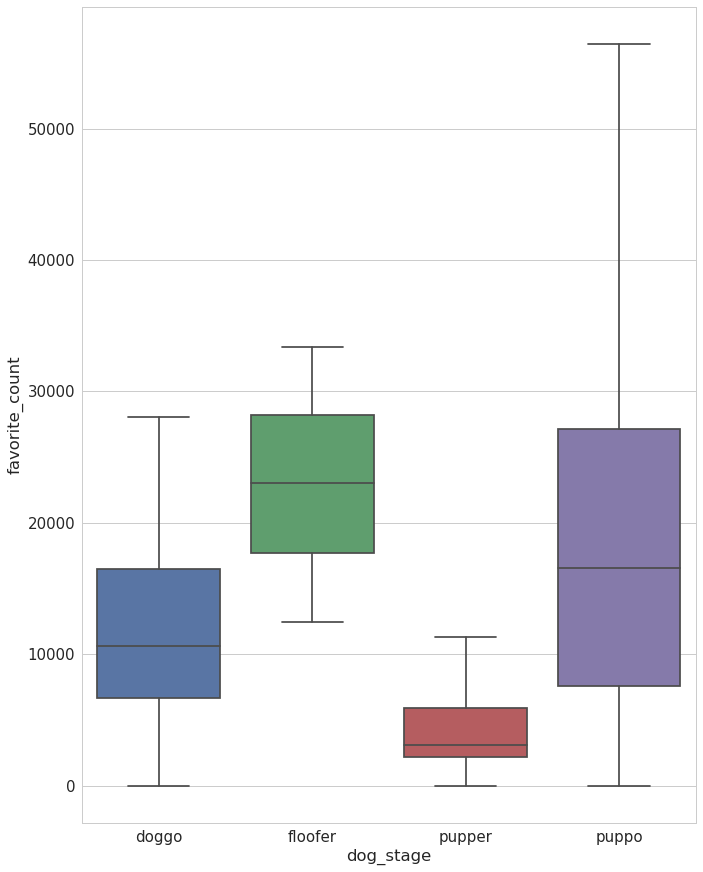

```python
sns.boxplot(data=main_df, x='dog_stage', y='favorite_count', showfliers=False)
```

### Comment

It is important to notice that the sample of floofer breed is very small (only 3 dogs of this breed). It cannot be considered as a representative sample. Puppo has much larger the maximum favorite count. On the other hand, pupper has much smaller maximum favorite count.

### Visualisation 2

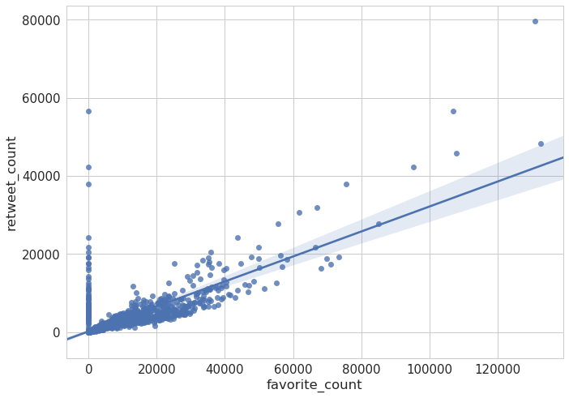

```python
ax = sns.regplot(x="favorite_count", y="retweet_count", data=main_df)
```

### Comment

On the scatter plot, one can notice a strong postive correlation between favorite count and retrieve count, which was expected. People retweet things that they love.

### Visualisation 3

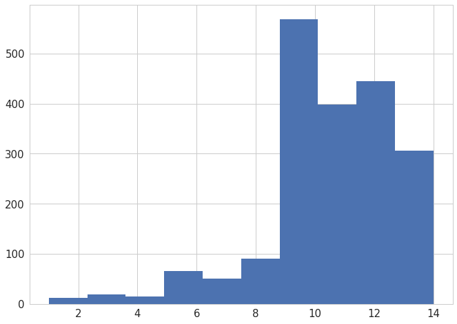

```python
plt.hist( x=main_df.rating_numerator)
```

### Comment

The distribution of ratings is left-skewed, which means that people evaluated dogs mostly in a positive way. People participate in these kind of activities to feel good. It probably satysfies this basic human need.